# DSI Workshop Time Series Anomaly Detection

by Oky Mauludany & Farhan Reza Gumay

9 October 2021

This is a hands-on session for DSI Workshop about Time Series Anomaly Detection presented by Tokopedia Data Analytics Team.

In this hands-on session, we will discuss 3 ways to detect anomaly in time series data :

1. Simple Moving Average
2. Standard Deviation + Moving Average
3. Analyze the Residuals from Time Series Decomposition using **anomalize** package

First, let import the package that needed for this hands-on session

```r
options(scipen=999) #To remove scientific notation
library(tidyverse)
library(tibbletime)
library(anomalize)
library(timetk)
library(zoo)
library(tidyquant)
library(forecast)
```

Then let’s load the data. For this, we already prepared the sample data from Google Analytics Public Data Sample about Traffic

```r
df = read.csv('C:/Users/nakama/Documents/time_series_sample_data_2.csv')
head(df)
```

```
##     date_key total_traffic
## 1 2021-01-01         17201
## 2 2021-01-02         17200
## 3 2021-01-03         17628
## 4 2021-01-04         18473
## 5 2021-01-05         18526
## 6 2021-01-06         18368
```

```r
str(df)
```

```
## 'data.frame':    273 obs. of  2 variables:
##  $ date_key     : chr  "2021-01-01" "2021-01-02" "2021-01-03" "2021-01-04" ...
##  $ total_traffic: int  17201 17200 17628 18473 18526 18368 18361 17993 17490 18273 ...
```

We can see that the **date_key** column is still in character format, so first we need to convert **date_key** column into Date data type.

```r
df$date_key <- as.Date(df$date_key,format = "%Y-%m-%d")
```

Let’s plot it with ggplot package to see how the timeseries data looks like.

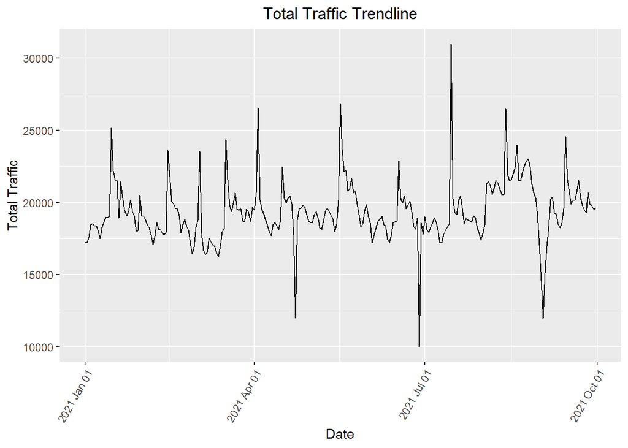

```r
plot_ts <- ggplot(df, aes(x = date_key, y = total_traffic)) +
  geom_line() +
  scale_x_date(date_labels = "%Y %b %d") +
  theme(axis.text.x=element_text(angle = 60, hjust = 1)) +
  theme(plot.title = element_text(hjust = 0.5)) +
  labs(title = 'Total Traffic Trendline', x = 'Date', y = 'Total Traffic')
plot_ts
```

If we take a look deeper into the data, there seems to be a seasonal jump trend every 1 month, so we will try to use **Moving Average 30 Days** for this 1st approach (note that this is just an example, you can use 7 days if your data have a trend on weekly level).

Let’s first add the column of Moving Average 30 Days, and then let’s plot the data.

```r
df$ma_30 <- rollapplyr(df[,2],list(-(30:1)), mean, fill = NA) # Calculating MA30
tail(df)
```

```
##       date_key total_traffic    ma_30
## 268 2021-09-25         19286 19357.03
## 269 2021-09-26         20695 19250.23
## 270 2021-09-27         19897 19232.23
## 271 2021-09-28         19802 19206.20
## 272 2021-09-29         19539 19188.50
## 273 2021-09-30         19582 19202.30
```

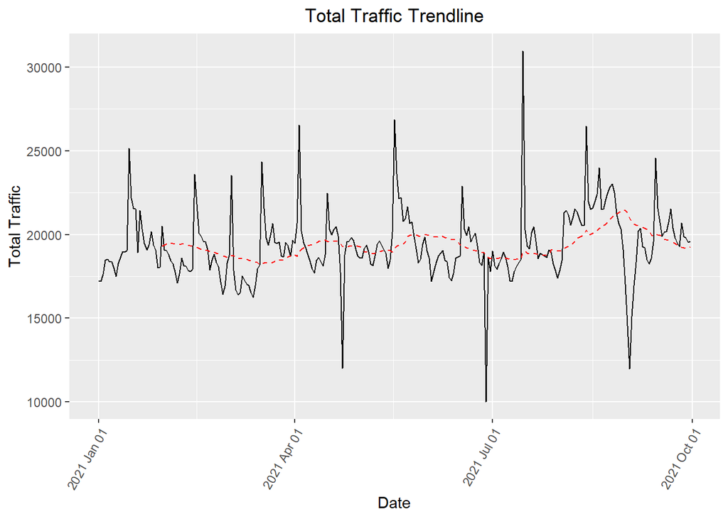

```r
# Plot the Time Series
plot_ts <- ggplot(df, aes(x = date_key, y = total_traffic)) +
  geom_line() +
  geom_ma(ma_fun = SMA, n = 30, color = 'red', show.legend = TRUE) +
  scale_x_date(date_labels = "%Y %b %d") +
  theme(axis.text.x=element_text(angle = 60, hjust = 1)) +
  theme(plot.title = element_text(hjust = 0.5)) +
  labs(title = 'Total Traffic Trendline', x = 'Date',  y = 'Total Traffic')
plot_ts
```

Looking the plot manually, we can already think that the data have some anomaly.

Let see if we can proof it using the model that we will create later.

**1. Simple Moving Average**

First, we will create a new column which is a % of difference between actual value and MA30 value as below.

```r
df <- df %>%
  mutate(pct_diff_actual_ma30 = (total_traffic - ma_30)/ma_30)
```

Then if we plot the distribution, we can see that the % of difference has normal distribution as below.

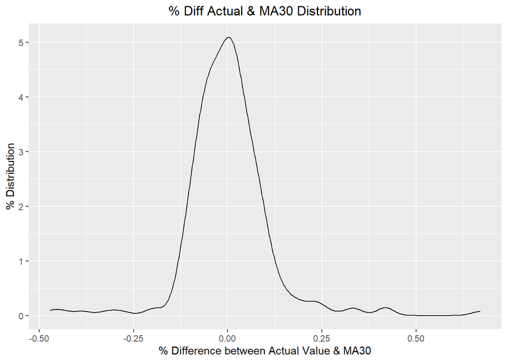

```r
# Plot the Distribution of % Difference of Actual Value & MA30
d <- ggplot(df, aes(x = pct_diff_actual_ma30)) +
  geom_density() +
  theme(plot.title = element_text(hjust = 0.5)) +
  labs(title = '% Diff Actual & MA30 Distribution', x = '% Difference between Actual Value & MA30', y = '% Distribution')

plot(d)
```

You are free to choose your own threshold, for example if for you the absolute difference **“>25%”** can already be considered as anomaly because it is suspicious, then goes with it.

For this example, we will use the **Normal Distribution Anomaly Rules**, that the anomaly are the data that falls **outside 3 standard deviation.**

Let’s calculate the upper and lower threshold of the % differences using **Normal Distribution Anomaly Rules** as stated before.

```r
standard_dev <- sd(df$pct_diff_actual_ma30, na.rm = TRUE) # Calculate the Standard Deviation from the Distribution
upper_thre <- mean(df$pct_diff_actual_ma30, na.rm = TRUE) + 3*standard_dev # Upper Threshold, anything above 3 Standard Deviation
lower_thre <- mean(df$pct_diff_actual_ma30, na.rm = TRUE) - 3*standard_dev # Lower Threshold, anything below 3 Standard Deviation

print(upper_thre)
```

```
## [1] 0.3396436
```

```r
print(lower_thre)
```

```
## [1] -0.3359468
```

We can see that the upper threshold is **~34%** while the lower threshold is **~33.5%**, that means if the **% of differences is higher than ~34% or lower than ~33.5%** then they will be classified as anomaly.

Now let’s add the **anomaly_flag** to the table.

```r
## Adding new column which is a flag whether an observation classified as anomaly or not
anomaly_upper <- df$pct_diff_actual_ma30 > upper_thre
anomaly_lower <- df$pct_diff_actual_ma30 < lower_thre
anomaly_flag_raw = anomaly_upper | anomaly_lower

df <- df %>%
  mutate(anomaly_flag_1 = anomaly_flag_raw)
df_anomaly_1 <- df %>%
  filter(df$anomaly_flag_1 == TRUE) %>%
  select(date_key, total_traffic, ma_30, pct_diff_actual_ma30) %>%
  mutate(event = 'Anomaly')
print(df_anomaly_1)
```

```
##     date_key total_traffic    ma_30 pct_diff_actual_ma30   event
## 1 2021-03-17         24361 18162.60            0.3412727 Anomaly
## 2 2021-04-03         26555 18705.80            0.4196132 Anomaly
## 3 2021-04-23         12012 19524.80           -0.3847824 Anomaly
## 4 2021-05-17         26879 18961.10            0.4175865 Anomaly
## 5 2021-06-28         10016 18952.20           -0.4715125 Anomaly
## 6 2021-07-15         30967 18546.93            0.6696561 Anomaly
## 7 2021-09-02         11972 21308.60           -0.4381611 Anomaly
```

We can see that using that rules, we will capture that there are 7 datas that considered as anomaly, and their differences with the MA30 is quite huge. Now let’s plot them to have a better interpretation of which data is classified as an anomaly.

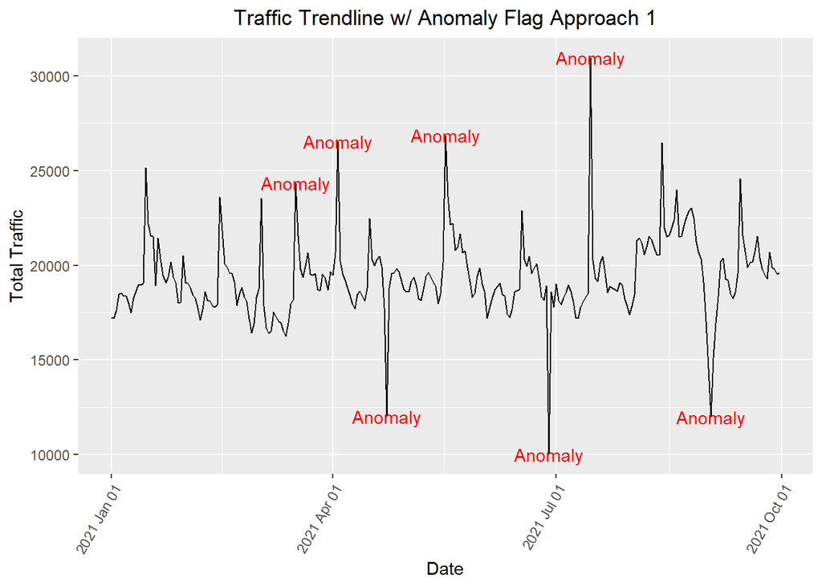

```r
plot_ts <- ggplot(NULL) +
  geom_line(df, mapping = aes(x=date_key, y=total_traffic)) +
  geom_text(data = df_anomaly_1, mapping = aes(x = date_key, y = total_traffic, label = event), color = 'red') +
  scale_x_date(date_labels = "%Y %b %d") +
  theme(axis.text.x = element_text(angle = 60, hjust = 1)) +
  theme(plot.title = element_text(hjust = 0.5)) +
  labs(title = 'Traffic Trendline w/ Anomaly Flag Approach 1', x = 'Date', y = 'Total Traffic')
plot_ts
```

Looking at the plot, we might think that :

- 17 March
- 3 April
- 17 May

isn’t really an anomaly, so if you think that’s the case that you want these 3 observations to not be classified as anomaly we can raise the upper threshold for this approach.

Now, let’s try to use the 2nd approach and compared the result with the 1st approach.

**2. Standard Deviation + Moving Average**

Another approach instead of using %of Difference is using Standard Deviation.

This approach is very similar to the 1st approach, but instead of presenting the difference in terms of % from MA30, we will measure the differenece in terms of **standard deviation unit**.

By using % of Difference, the threshold is always same over the time. So imagine if at one time it is normal that our traffic is being volatile, that means many data point will captured as anomaly. But using standard deviation means we also adjust the threshold over the time

Let’s first add a new column that is the standard deviation of Last 30 Days, and then add another column which is the difference of actual value and MA30 in standard deviation unit.

```r
df$sd_30 <- rollapplyr(df[,2],list(-(30:1)), sd, fill=NA) #Calculating Standard Deviation for Last 30 Days

df <- df %>%
  mutate(sd_diff = (total_traffic - ma_30)/sd_30)
tail(df)
```

```
##       date_key total_traffic    ma_30 pct_diff_actual_ma30 anomaly_flag_1
## 268 2021-09-25         19286 19357.03         -0.003669639          FALSE
## 269 2021-09-26         20695 19250.23          0.075051904          FALSE
## 270 2021-09-27         19897 19232.23          0.034565235          FALSE
## 271 2021-09-28         19802 19206.20          0.031021233          FALSE
## 272 2021-09-29         19539 19188.50          0.018266149          FALSE
## 273 2021-09-30         19582 19202.30          0.019773673          FALSE
##        sd_30     sd_diff
## 268 2433.592 -0.02918867
## 269 2360.568  0.61204192
## 270 2346.931  0.28324931
## 271 2334.641  0.25519988
## 272 2327.806  0.15057096
## 273 2328.644  0.16305629
```

Now, let’s see the distribution of those difference.

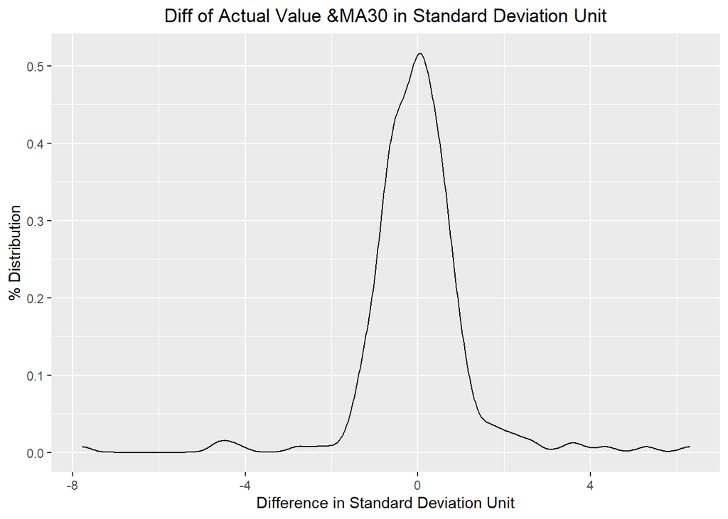

```r
d <- ggplot(df, aes(x = sd_diff)) +
  geom_density() +
  theme(plot.title = element_text(hjust = 0.5)) +
  labs(title = 'Diff of Actual Value &MA30 in Standard Deviation Unit', x='Difference in Standard Deviation Unit', y='% Distribution')

plot(d)
```

Let’s use the same approach with **Normal Distribution Anomaly Rules**, that using 3 standard deviation from the distribution as a threshold.

```r
standard_dev <- sd(df$sd_diff, na.rm = TRUE) # Calculate the Standard Deviation from the Distribution
upper_thre <- mean(df$sd_diff, na.rm = TRUE) + 3*standard_dev # Upper Threshold, anything above 3 Standard Deviation
lower_thre <- mean(df$sd_diff, na.rm = TRUE) - 3*standard_dev # Lower Threshold, anything below 3 Standard Deviation

## Adding new column which is a flag whether an observation classified as anomaly or not
anomaly_upper <- df$sd_diff > upper_thre
anomaly_lower <- df$sd_diff < lower_thre
anomaly_flag_raw = anomaly_upper | anomaly_lower

df <- df %>%
  mutate(anomaly_flag_2 = anomaly_flag_raw)
df_anomaly_2 <- df %>%
  filter(df$anomaly_flag_2 == TRUE) %>%
  select(date_key, total_traffic, ma_30, pct_diff_actual_ma30, sd_diff) %>%
  mutate(event = 'Anomaly')
print(df_anomaly_2)
```

```
##     date_key total_traffic    ma_30 pct_diff_actual_ma30   sd_diff   event
## 1 2021-03-17         24361 18162.60            0.3412727  3.727228 Anomaly
## 2 2021-04-03         26555 18705.80            0.4196132  4.351645 Anomaly
## 3 2021-04-23         12012 19524.80           -0.3847824 -4.489424 Anomaly
## 4 2021-05-17         26879 18961.10            0.4175865  5.296055 Anomaly
## 5 2021-06-28         10016 18952.20           -0.4715125 -7.792549 Anomaly
## 6 2021-07-15         30967 18546.93            0.6696561  6.296595 Anomaly
## 7 2021-09-01         14557 21437.70           -0.3209626 -4.159178 Anomaly
## 8 2021-09-02         11972 21308.60           -0.4381611 -4.645007 Anomaly
```

Let’s plot them to have a better understanding of which one is classified as anomaly.

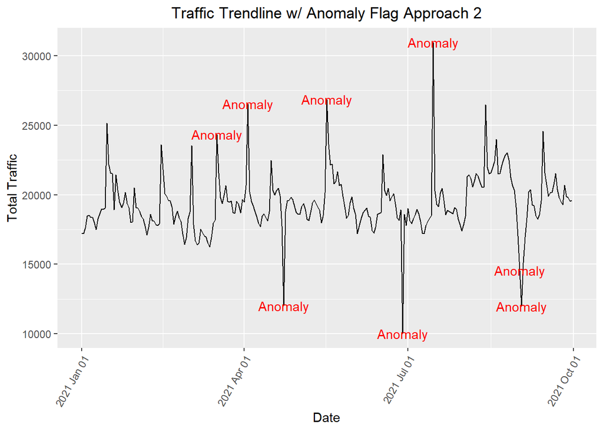

```r
plot_ts <- ggplot(NULL) +
  geom_line(df, mapping = aes(x = date_key, y = total_traffic)) +
  geom_text(data = df_anomaly_2, mapping = aes(x = date_key, y = total_traffic, label = event), color = 'red') +
  scale_x_date(date_labels = "%Y %b %d") +
  theme(axis.text.x = element_text(angle = 60, hjust = 1)) +
  theme(plot.title = element_text(hjust = 0.5)) +
  labs(title = 'Traffic Trendline w/ Anomaly Flag Approach 2', x = 'Date', y = 'Total Traffic')
plot_ts
```

It basically yield almost the same result with **Approach 1**, except that with this approach **1 September** is also classified as an anomaly.

Also, as explain before, this is basically similar to what already known as **Bollinger Bands** in stocks technical analysis.

Just for your information, usually in stocks use this threshold :

- Short Term : 1.5 Standard Deviations
- Medium Term : 2 Stanadard Deviations
- Long Term : 2.5 Standard Deviations

Not let’s try to use anomalize package!

**3. Using anomalize Package**

Let’s first create a new dataframe for this approach,as this package needs the input in form of tibble.

```r
df_new = read.csv('C:/Users/nakama/Documents/time_series_sample_data_2.csv')
df_new$date_key <- as.Date(df_new$date_key,format="%Y-%m-%d")
df_new <- as_tibble(df_new) #anomalize package need input to be in tibble format
```

On time series decomposition, there are several time series components :

1. Seasonal
2. Trend
3. Remainder

$$y_t = S_t + T_t + R_t$$

$$y_t : Actual Value$$
$$S_t : Seasonal$$
$$T_t : Trend$$
$$R_t : Remainder$$

The decompisition here is using *STL* method. STL stands for **Seasonal and Trend decomposition using Loess** as already explained in session before.

**anomalize** have 2 options method in detecting residuals that are anomalies :

1. IQR : InterQuartile Range, it is a similar method used in tsoutliers() function of the forecast package. In IQR a distribution is taken and 25% and 75% inner quartile range to establish the distribution of the remainder. Limits are set by default to a factor of 3 times above, and below the inner quartile range, any remainder beyond the limit is considered as an anomaly.
2. GESD : Generalized Extreme Studentized Deviate Test, in GESD anomalies are progressively evaluated removing the worst offenders and recalculating the test statistics and critical values, or more simply you can say that a range is recalculated after identifying the anomalies in an iterative way.

Both IQR and GESD have their pros and cons, IQR is faster as there are no loops involved but it’s not as accurate as GESD since the anomalies skews the median which is removed in GESD.

Below is the image of how the time series data sample that we have is we decomposed them into **seasonal, trend, and remainder**

```
## Converting from tbl_df to tbl_time.
## Auto-index message: index = date_key
```

```
## frequency = 7 days
```

```
## trend = 30 days
```

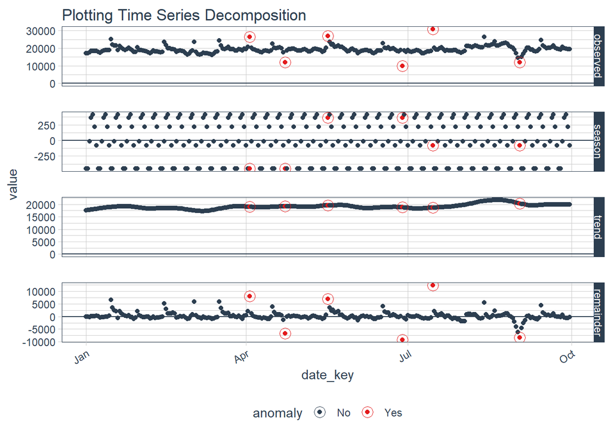

```r
df_new %>%
  time_decompose(total_traffic, trend = 30, merge=TRUE) %>% #Decomposition Part
  anomalize(remainder, method='gesd', max_anoms = 0.025) %>% #Analyze the Residuals/Remainders
  time_recompose() %>%
  plot_anomaly_decomposition() +
  ggtitle("Plotting Time Series Decomposition")
```

Let’s print which observations is classified as anomaly

```
## Converting from tbl_df to tbl_time.
## Auto-index message: index = date_key
```

```
## frequency = 7 days
```

```
## trend = 30 days
```

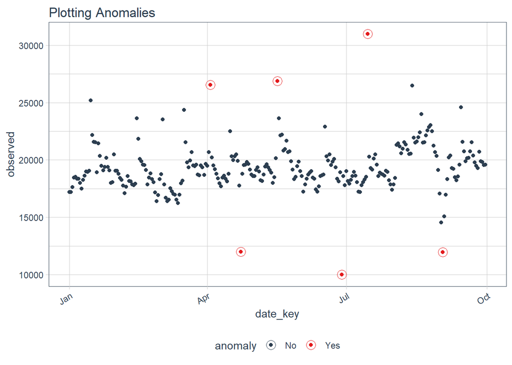

```r
df_new %>%
  time_decompose(total_traffic, trend = 30, merge=TRUE) %>% #Decomposition Part
  anomalize(remainder, method='gesd', max_anoms = 0.025) %>% #Analyze the Residuals/Remainders
  time_recompose() %>%
  plot_anomalies() +
  ggtitle("Plotting Anomalies")
```

```r
df_new %>%
  time_decompose(total_traffic, trend = 30, merge=TRUE) %>%
  anomalize(remainder, method='gesd', max_anoms = 0.025) %>%
  time_recompose() %>%
  glimpse() %>%
  as.data.frame() %>%
  filter(anomaly == 'Yes')
```

```
## Converting from tbl_df to tbl_time.
## Auto-index message: index = date_key
```

```
## frequency = 7 days
```

```
## trend = 30 days
```

```
## Rows: 273
## Columns: 11
## $ date_key      <date> 2021-01-01, 2021-01-02, 2021-01-03, 2021-01-04, 2021-01~
## $ total_traffic <int> 17201, 17200, 17628, 18473, 18526, 18368, 18361, 17993, ~
## $ observed      <dbl> 17201, 17200, 17628, 18473, 18526, 18368, 18361, 17993, ~
## $ season        <dbl> -453.14112, -449.01429, -16.72183, 365.84657, 414.78515,~
## $ trend         <dbl> 17627.59, 17723.23, 17818.87, 17914.52, 18009.73, 18104.~
## $ remainder     <dbl> 26.54965, -74.21855, -174.15239, 192.63783, 101.48612, 4~
## $ remainder_l1  <dbl> -2721.754, -2721.754, -2721.754, -2721.754, -2721.754, -~
## $ remainder_l2  <dbl> 2662.965, 2662.965, 2662.965, 2662.965, 2662.965, 2662.9~
## $ anomaly       <chr> "No", "No", "No", "No", "No", "No", "No", "No", "No", "N~
## $ recomposed_l1 <dbl> 14452.70, 14552.46, 15080.40, 15558.61, 15702.76, 15603.~
## $ recomposed_l2 <dbl> 19837.42, 19937.18, 20465.12, 20943.33, 21087.48, 20988.~
```

```
##     date_key total_traffic observed     season    trend remainder remainder_l1
## 1 2021-04-03         26555    26555 -449.01429 18992.77  8011.247    -2721.754
## 2 2021-04-23         12012    12012 -453.14112 19249.85 -6784.712    -2721.754
## 3 2021-05-17         26879    26879  365.84657 19601.21  6911.946    -2721.754
## 4 2021-06-28         10016    10016  365.84657 18811.49 -9161.340    -2721.754
## 5 2021-07-15         30967    30967  -81.86688 18667.43 12381.434    -2721.754
## 6 2021-09-02         11972    11972  -81.86688 20350.14 -8296.273    -2721.754
##   remainder_l2 anomaly recomposed_l1 recomposed_l2
## 1     2662.965     Yes      15822.00      21206.72
## 2     2662.965     Yes      16074.96      21459.68
## 3     2662.965     Yes      17245.30      22630.02
## 4     2662.965     Yes      16455.59      21840.30
## 5     2662.965     Yes      15863.81      21248.53
## 6     2662.965     Yes      17546.52      22931.24
```

From the data above, **recomposed_l1** is the lower bound of outliers around the observed values, while **recomposed_l2** is the upper bound.

Let’s try to increase to adjust the parameter that at max **3%** of data that can be classified as anomaly.

```
## Converting from tbl_df to tbl_time.
## Auto-index message: index = date_key
```

```
## frequency = 7 days
```

```
## trend = 30 days
```

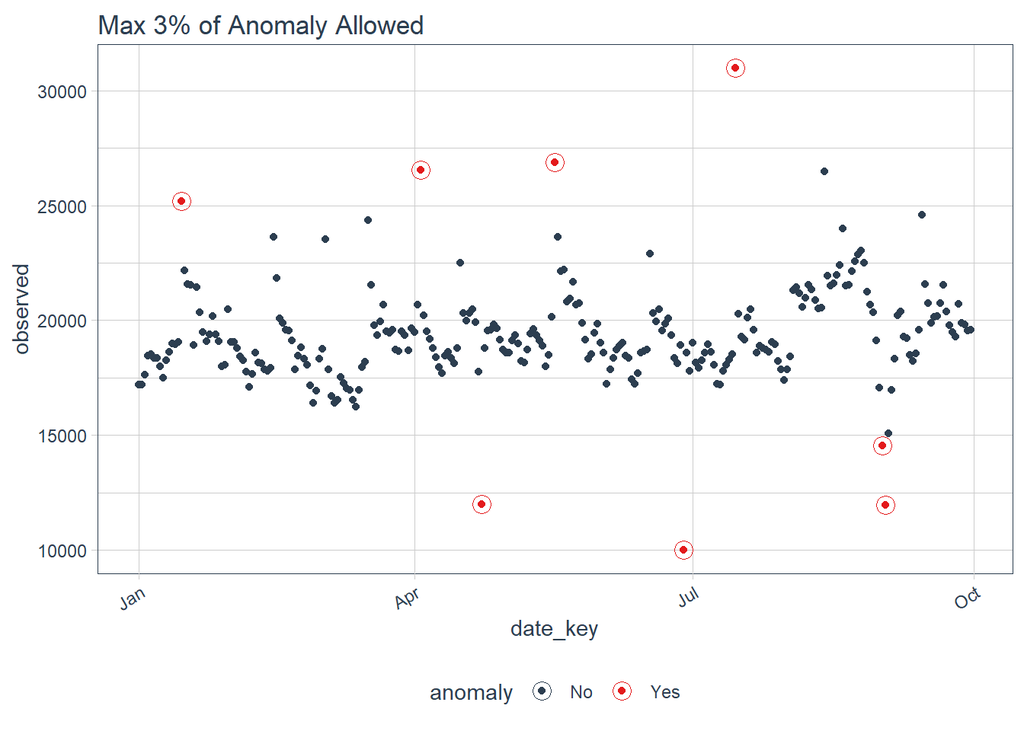

```r
df_new %>%
  time_decompose(total_traffic, trend=30, merge=TRUE) %>%
  anomalize(remainder, method='gesd', max_anoms = 0.03) %>%
  time_recompose() %>%
  plot_anomalies() +
  ggtitle("Max 3% of Anomaly Allowed")
```

```r
df_new %>%
  time_decompose(total_traffic, trend = 30, merge=TRUE) %>%
  anomalize(remainder, method='gesd', max_anoms = 0.03) %>%
  time_recompose() %>%
  glimpse() %>%
  as.data.frame() %>%
  filter(anomaly == 'Yes')
```

```
## Converting from tbl_df to tbl_time.
## Auto-index message: index = date_key
```

```
## frequency = 7 days
```

```
## trend = 30 days
```

```
## Rows: 273
## Columns: 11
## $ date_key      <date> 2021-01-01, 2021-01-02, 2021-01-03, 2021-01-04, 2021-01~
## $ total_traffic <int> 17201, 17200, 17628, 18473, 18526, 18368, 18361, 17993, ~
## $ observed      <dbl> 17201, 17200, 17628, 18473, 18526, 18368, 18361, 17993, ~
## $ season        <dbl> -453.14112, -449.01429, -16.72183, 365.84657, 414.78515,~
## $ trend         <dbl> 17627.59, 17723.23, 17818.87, 17914.52, 18009.73, 18104.~
## $ remainder     <dbl> 26.54965, -74.21855, -174.15239, 192.63783, 101.48612, 4~
## $ remainder_l1  <dbl> -2662.9, -2662.9, -2662.9, -2662.9, -2662.9, -2662.9, -2~
## $ remainder_l2  <dbl> 2604.111, 2604.111, 2604.111, 2604.111, 2604.111, 2604.1~
## $ anomaly       <chr> "No", "No", "No", "No", "No", "No", "No", "No", "No", "N~
## $ recomposed_l1 <dbl> 14511.55, 14611.32, 15139.25, 15617.46, 15761.61, 15662.~
## $ recomposed_l2 <dbl> 19778.56, 19878.33, 20406.26, 20884.47, 21028.62, 20929.~
```

```
##     date_key total_traffic observed     season    trend remainder remainder_l1
## 1 2021-01-15         25167    25167 -453.14112 18923.14  6696.998      -2662.9
## 2 2021-04-03         26555    26555 -449.01429 18992.77  8011.247      -2662.9
## 3 2021-04-23         12012    12012 -453.14112 19249.85 -6784.712      -2662.9
## 4 2021-05-17         26879    26879  365.84657 19601.21  6911.946      -2662.9
## 5 2021-06-28         10016    10016  365.84657 18811.49 -9161.340      -2662.9
## 6 2021-07-15         30967    30967  -81.86688 18667.43 12381.434      -2662.9
## 7 2021-09-01         14557    14557  220.11239 20509.87 -6172.986      -2662.9
## 8 2021-09-02         11972    11972  -81.86688 20350.14 -8296.273      -2662.9
##   remainder_l2 anomaly recomposed_l1 recomposed_l2
## 1     2604.111     Yes      15807.10      21074.11
## 2     2604.111     Yes      15880.85      21147.86
## 3     2604.111     Yes      16133.81      21400.82
## 4     2604.111     Yes      17304.15      22571.16
## 5     2604.111     Yes      16514.44      21781.45
## 6     2604.111     Yes      15922.67      21189.68
## 7     2604.111     Yes      18067.09      23334.10
## 8     2604.111     Yes      17605.37      22872.38
```

Now let’s compile them together in one table!

```r
df$anomaly_flag_3_1 <- df_new %>%
  time_decompose(total_traffic, trend = 30, merge=TRUE) %>%
  anomalize(remainder, method='gesd', max_anoms = 0.025) %>%
  time_recompose() %>%
  glimpse() %>%
  as.data.frame() %>%
  select(anomaly)
```

```
## Rows: 273
## Columns: 11
## $ date_key      <date> 2021-01-01, 2021-01-02, 2021-01-03, 2021-01-04, 2021-01~
## $ total_traffic <int> 17201, 17200, 17628, 18473, 18526, 18368, 18361, 17993, ~
## $ observed      <dbl> 17201, 17200, 17628, 18473, 18526, 18368, 18361, 17993, ~
## $ season        <dbl> -453.14112, -449.01429, -16.72183, 365.84657, 414.78515,~
## $ trend         <dbl> 17627.59, 17723.23, 17818.87, 17914.52, 18009.73, 18104.~
## $ remainder     <dbl> 26.54965, -74.21855, -174.15239, 192.63783, 101.48612, 4~
## $ remainder_l1  <dbl> -2721.754, -2721.754, -2721.754, -2721.754, -2721.754, -~
## $ remainder_l2  <dbl> 2662.965, 2662.965, 2662.965, 2662.965, 2662.965, 2662.9~
## $ anomaly       <chr> "No", "No", "No", "No", "No", "No", "No", "No", "No", "N~
## $ recomposed_l1 <dbl> 14452.70, 14552.46, 15080.40, 15558.61, 15702.76, 15603.~
## $ recomposed_l2 <dbl> 19837.42, 19937.18, 20465.12, 20943.33, 21087.48, 20988.~
```

```r
df$anomaly_flag_3_2 <- df_new %>%
  time_decompose(total_traffic, trend = 30, merge=TRUE) %>%
  anomalize(remainder, method='gesd', max_anoms = 0.03) %>%
  time_recompose() %>%
  glimpse() %>%
  as.data.frame() %>%
  select(anomaly)
```

```
## Rows: 273
## Columns: 11
## $ date_key      <date> 2021-01-01, 2021-01-02, 2021-01-03, 2021-01-04, 2021-01~
## $ total_traffic <int> 17201, 17200, 17628, 18473, 18526, 18368, 18361, 17993, ~
## $ observed      <dbl> 17201, 17200, 17628, 18473, 18526, 18368, 18361, 17993, ~
## $ season        <dbl> -453.14112, -449.01429, -16.72183, 365.84657, 414.78515,~
## $ trend         <dbl> 17627.59, 17723.23, 17818.87, 17914.52, 18009.73, 18104.~
## $ remainder     <dbl> 26.54965, -74.21855, -174.15239, 192.63783, 101.48612, 4~
## $ remainder_l1  <dbl> -2662.9, -2662.9, -2662.9, -2662.9, -2662.9, -2662.9, -2~
## $ remainder_l2  <dbl> 2604.111, 2604.111, 2604.111, 2604.111, 2604.111, 2604.1~
## $ anomaly       <chr> "No", "No", "No", "No", "No", "No", "No", "No", "No", "N~
## $ recomposed_l1 <dbl> 14511.55, 14611.32, 15139.25, 15617.46, 15761.61, 15662.~
## $ recomposed_l2 <dbl> 19778.56, 19878.33, 20406.26, 20884.47, 21028.62, 20929.~
```

```r
df %>%
  filter(anomaly_flag_1 == TRUE | anomaly_flag_2 == TRUE | anomaly_flag_3_1 == 'Yes' | anomaly_flag_3_2 == 'Yes') %>%
  select(date_key, total_traffic, ma_30, pct_diff_actual_ma30, sd_diff, anomaly_flag_1, anomaly_flag_2, anomaly_flag_3_1, anomaly_flag_3_2)
```

```
##     date_key total_traffic    ma_30 pct_diff_actual_ma30   sd_diff
## 1 2021-01-15         25167       NA                   NA        NA
## 2 2021-03-17         24361 18162.60            0.3412727  3.727228
## 3 2021-04-03         26555 18705.80            0.4196132  4.351645
## 4 2021-04-23         12012 19524.80           -0.3847824 -4.489424
## 5 2021-05-17         26879 18961.10            0.4175865  5.296055
## 6 2021-06-28         10016 18952.20           -0.4715125 -7.792549
## 7 2021-07-15         30967 18546.93            0.6696561  6.296595
## 8 2021-09-01         14557 21437.70           -0.3209626 -4.159178
## 9 2021-09-02         11972 21308.60           -0.4381611 -4.645007
##   anomaly_flag_1 anomaly_flag_2 anomaly anomaly
## 1             NA             NA      No     Yes
## 2           TRUE           TRUE      No      No
## 3           TRUE           TRUE     Yes     Yes
## 4           TRUE           TRUE     Yes     Yes
## 5           TRUE           TRUE     Yes     Yes
## 6           TRUE           TRUE     Yes     Yes
## 7           TRUE           TRUE     Yes     Yes
## 8          FALSE           TRUE      No     Yes
## 9           TRUE           TRUE     Yes     Yes
```